# Motion Sensing for Exercise Coaching

Steven J. Rigatti

Monday, February 16, 2015

## Introduction

This paper is submitted in fulfillment of the course project for the Coursera Machine Learning course in the Data Science specialization. The task of this project was to use techniques learned in the course to produce a classifier which accurately predicts whether or not single-armed dumbbell curls are being performed correctly and, if not, what specific technical mistake is being made. The data come from Groupware@LES and is part of their Human Activity Recognition project. Their finding on this data have been published here (Velloso, E.; Bulling, A.; Gellersen, H.; Ugulino, W.; Fuks, H. Qualitative Activity Recognition of Weight Lifting Exercises. Proceedings of 4th Augmented Human (AH) International Conference in cooperation with ACM SIGCHI (Augmented Human’13) . Stuttgart, Germany: ACM SIGCHI, 2013). This publication details the experimental set up. Briefly, researcher had 6 subject perform single-arm dumbbell curls while wearing 4 multi-axial motion sensors (one each on the dumbbell, belt, arm and wrist). Subjects then performed the exercise using proper technique, and then using 4 different improper techniques. The goal was to develop an algorithm to detect both proper and specific improper techniques in order to be able to “coach” an individual performing these exercises in the future. Methodologically, the authors used summary measures as predictors in a random forest analysis and achieved 98% accuracy on 10-fold cross validation, and 78% accuracy on leave-one-out cross validation.

In the current paper, a random forest technique is used to produce a classifier, using the raw data, without summary measures, which correctly predicted 95% of the outcome variables in the test data.

### Exploratory Analysis and Data Processing

The data consist of 19,622 observations of 160 variables. The variables included raw measurements from the gyroscopes, accelerometers and magnetometers used in the experiment. It also included 406 rows of summary measures (min, max, standard deviation, variance, skew and kurtosis) for each new window of observation. In all, there were 100 columns of summary measures, and these were deleted so as to build the models on the raw data. Once these columns were deleted, it left 19,622 observations of 60 variables. Investigation of the correlations between variables revealed many strongly co-linear pairs of variables - 11 pairs with r-values >0.9. The correlations may sense mechanistically. For example, the roll measurement from the belt sensor correlated strongly with the total acceleration measurement from the belt (see Figure 1). No further numerical changes or adjustments were made to the data.

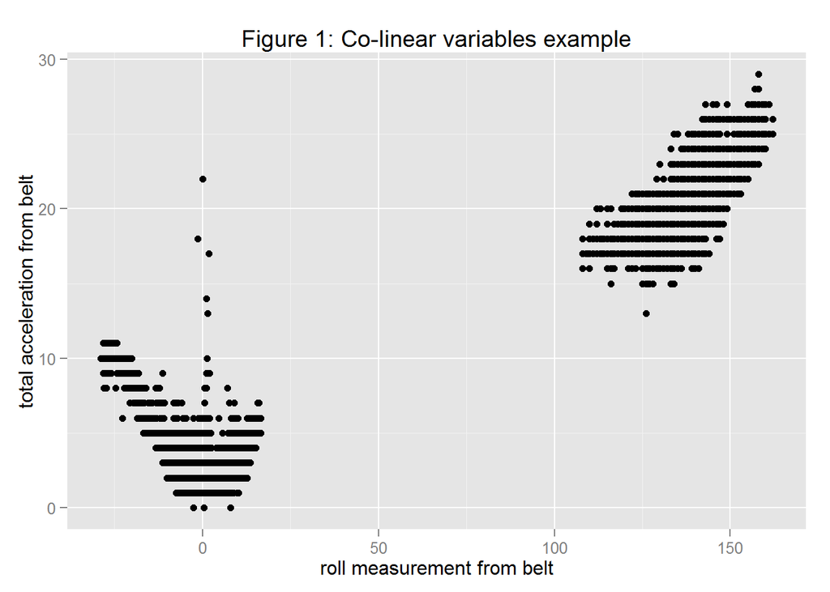

Further inspection of the data revealed that there were several variables which, logically, should not be used as predictors in order to avoid over-fitting and provide for better generalization of the algorithm. Specifically, the names of the subjects should not be used since the purpose of the project is to identify exercise quality on new users. Also, the raw time stamps should have nothing at all to do with whether or not an exercise is performed correctly. Finally the window number variable may be prone to over-fitting since it seems to correlate cyclically with the ‘classe’ variable (Figure 2). These variables were not used as predictors in the models analyzed.

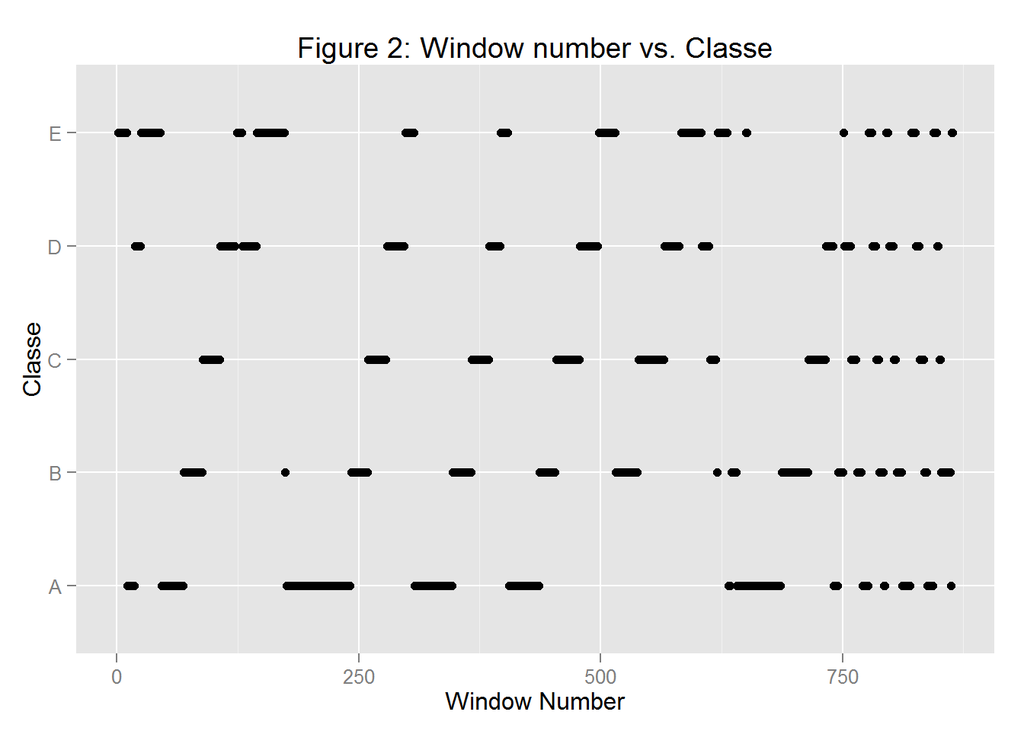

### Methods

The random forest technique was used as a classification algorithm to predict the ‘classe’ variable based only on raw measurements from the motion sensors. The choice of random forest was made because it is robust to both co-linear and non-linear variable:outcome relationships. The random forest was implemented with 500 trees, testing 7 random predictors at each node. Variable importance was collected. Figure 3 demonstrates the Gini index reduction measure for the 20 most important variables. The out-of-bag (OOB) error rate was 0.27% on this initial run. A second attempt was made, this time pre-processing the data using principal component analysis. The resulting random forest model had an OOB error rate of 1.36%, which was more in line with what the authors achieved in their original paper.

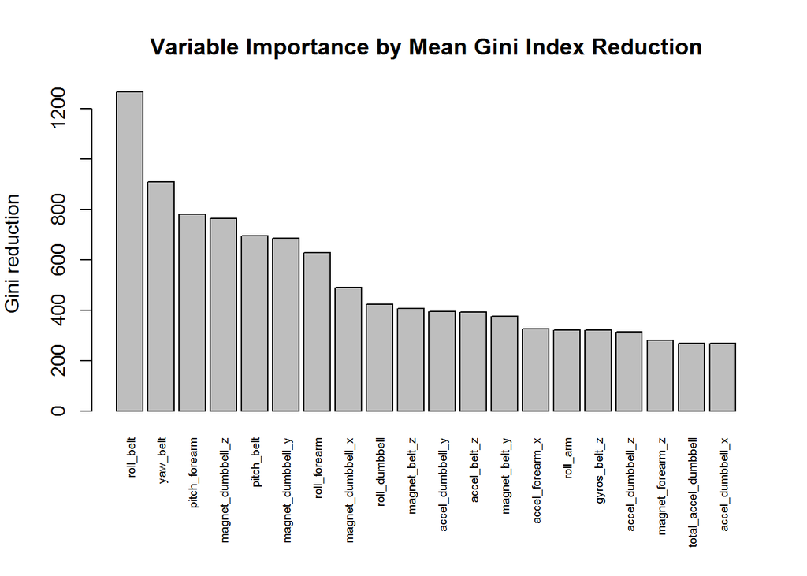

Next, cross-validation (beyond that supplied by the OOB error rate) was attempted. The expectation here was that the cross validation should perform slightly less well than the OOB error. Since the study consisted of 6 subjects, it was decided to perform a 6-fold cross validation where each subject was left out of the training of the model, and then used as validation. This is called leave-one-subject out (LOSO) cross-validation. This choice was made because it is consistent with the overall aims of the study. For each fold, a 500 tree random forest was fit with the same parameters as previously specified (without collection of variable importance). This was done both with and without pre-processing by PCA. The accuracy on cross validation was rather low: 37.6% without PCA and 22.5% with it. This surprising result may have been due to individual subjects having peculiarities with respect to their various techniques and that is lost when holding out the entire individual. So, another round of cross-validation was performed, this time a 5-fold cross validation using a random permutation of the observations. This time the overall accuracy was 99.3%.

## Appendix

Code used. Note, if you try to run this you can save yourself some time by turning the ntree variable down to 20. The results are similar.

```r
library(caret)
library(randomForest)
x<-read.csv("pml-training.csv", na.strings=c("","NA"))
sum(is.na(x))

z<-apply(x,2,function(y) {sum(is.na(y))})

#raw data only
x<-x[,z==0]
sum(is.na(x))



z<-abs(cor(x[,c(8:59)]))
sum(z<1 & z>0.9)
diag(z)<-0
which(z>0.9,arr.ind=T)
##Fig 1
qplot(x$roll_belt,x$total_accel_belt,xlab="roll measurement from belt",ylab="total acceleration from belt",
      main="Figure 1: Co-linear variables example")
## roll_belt with total_accel_belt, accel_belt_y and accel_belt_z
## pitch_belt with accel_belt_x
## total-accel_belt with accel_belt_z
##accel_belt_y with total_accel_belt and accel_belt_z
## gyros_arm_y with gyros_arm_x
##gyros_dumbell_x with gyros_dumbell_z and gyros_forearm-z
## gyros_dumbell_z with gyros_forearm_z

m1<-randomForest(classe~.,ntree=500,importance=TRUE,do.trace=FALSE,data=x)
#OOB error is only 0.01% - but could be overfit
##First 7 columns are not measurements from the instruments and could
##Bias the analysis - will remove

m2<-randomForest(classe~.,ntree=500,importance=TRUE,do.trace=TRUE,data=x[,-c(1:7)])
#OOB error is 0.27%

#plot 2 showing possible correlation with num_window variable
qplot(x$num_window,x$classe,xlab="Window Number",ylab="Classe",
      main="Figure 2: Window number vs. Classe")

#plot 3 showing variable importance measure
imp<-sort(m2$importance[,7],decreasing=TRUE)

par(mar=c(7,4,4,2))
barplot(imp[1:20,2],las=3,cex.names=0.6, main="Variable Importance by Mean Gini Index Reduction",
        ylab="Gini reduction",names.arg=imp[1:20,1])
par(mar=c(5,4,4,2)+.1)

#try PCA fit
smallx<-x[,-c(1:7,60)]
PCA<-prcomp(smallx)

pca.x<-data.frame(cbind(PCA$x,x$classe))
names(pca.x)[53]<-"classe"
pca.x$classe<-factor(pca.x$classe)
pca.rf<-randomForest(classe~.,ntree=500,importance=FALSE,do.trace=TRUE,data=pca.x)
## OOB error is 1.36%

#cross validation: leave one subject out
subject.names<-levels(x$user_name)
xv.rf<-list(NULL)

for(i in 1:6){
        #hold out each subject in turn
        hold.out.index<-which(x$user_name==subject.names[i])
        xv.train<-x[-hold.out.index,-c(1:7)]
        xv.test<-x[hold.out.index,-c(1:7)]
        #train a model using the other 5 subject
        rf.xv<-randomForest(classe~.,ntree=500,importance=FALSE,do.trace=TRUE,data=xv.train,forest=TRUE)
        #predict on held out subject
        prediction<-predict(rf.xv,xv.test)
        xv.rf[i]<-confusionMatrix(prediction,xv.test$classe)$overall[1]
}
mean(unlist(xv.rf))

#Same for pca
xv.rfp<-list(NULL)
for(i in 1:6){
        #hold out each subject in turn
        hold.out.index<-which(x$user_name==subject.names[i])
        xv.train<-x[-hold.out.index,-c(1:7)]
        xv.test<-x[hold.out.index,-c(1:7)]
        #train a model using the other 5 subject
        pca.train<-prcomp(xv.train[,-53])
        pca.test<-predict(pca.train,xv.test)

        pca.train.df<-data.frame(pca.train$x,classe=xv.train$classe)
        pca.train.df$classe<-factor(pca.train.df$classe)
        rfp<-randomForest(classe~.,ntree=500,importance=FALSE,do.trace=TRUE,data=pca.train.df)
        #predict on held out subject
        prediction<-predict(rfp,pca.test)
        xv.rfp[i]<-confusionMatrix(prediction,xv.test$classe)$overall[1]
}
#Low cross validaiton accuracy this way
mean.unlist(xv.rfp)

##5-fold random x-validation
set.seed(123)
sample<-sample(x$X)
xv.xs<-list(NULL)
for(i in seq(1:5)){
        j<-3924*(i-1)+1
        k<-3924*i
        xs.train<-x[-sample[j:k],-c(1:7)]
        xs.test<-x[sample[j:k],-c(1:7)]

        rf.xs<-randomForest(classe~.,ntree=500,importance=FALSE,do.trace=TRUE,forest=TRUE,data=xs.train)
        xs.predict<-predict(rf.xs,xs.test)

        confusionMatrix(xs.predict,xs.test$classe)
        xv.xs[i]<-confusionMatrix(xs.predict,xs.test$classe)$overall[1]
}
mean(unlist(xv.xs))

answers<-predict(m2,testing)
pca.test<-predict(PCA,testing)
answers2<-predict(pca.rf,pca.test)
answers2
```